# Assignment4-Question2

AlexanderJefferies

2022-06-08

```r
library(qicharts2)
library(dplyr)
data <- read.csv("monitor.csv")

data$Timestamp <- as.POSIXct(data$Timestamp,format='%Y-%m-%d %H:%M:%OS')

##adding a day of year column ot
s_1 <- as.Date(data$Timestamp,format='%Y-%m-%d')
data$DayOfYear <- lubridate::yday(s_1)


head(data)
```

```
##             Timestamp ProcessMemory Prediction PredictionTimeMS DayOfYear
## 1 2020-02-01 13:42:26      9.016455   67.71810         338.7008        32
## 2 2020-02-01 13:52:24      9.130453   51.72398         338.5344        32
## 3 2020-02-01 13:54:13      9.089923   65.86389         471.5026        32
## 4 2020-02-01 14:16:07      9.549547   66.72274         364.4351        32
## 5 2020-02-01 14:19:35      8.785758   57.87888         455.2207        32
## 6 2020-02-01 14:21:05      9.218839   55.93344         344.9703        32
```

### Memory Usage

1. Is the memory usage of the server in control?

See results of an xbar chart for memory usage below:

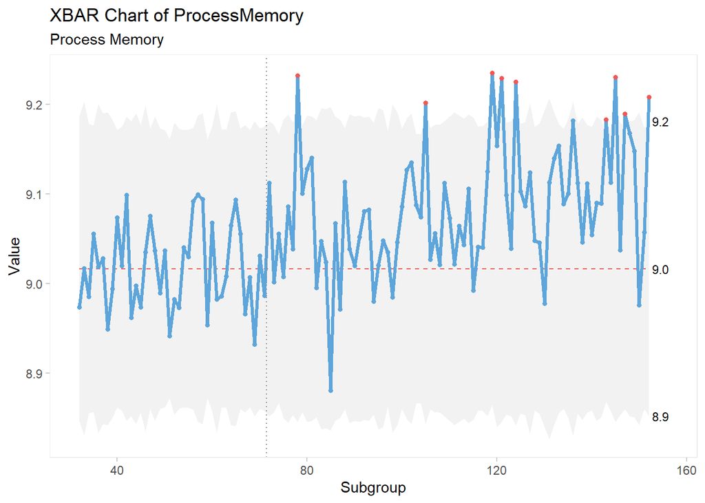

```r
control_set <- 40 ##40 day period to gauge in control values

##testing for means in control
p1 <- qicharts2::qic(x = DayOfYear, y = ProcessMemory, data = data, freeze=control_set,chart = "xbar", subtitle = "Process Memory")
plot(p1)
```

```r
summary(p1)
```

```
##   facet1 facet2 part n.obs n.useful longest.run longest.run.max n.crossings
## 1      1      1    1   121      121          19              10          39
##   n.crossings.min runs.signal     aLCL       CL     aUCL sigma.signal
## 1              51           1 8.851066 9.016781 9.182495            9
```

```r
  #select(runs.signal, sigma.signal)
```

Memory Usage means are out of control as 9 points fall beyond the control limits. Firstly, to confirm this, the longest run has a value of 19 compared with a max.longest.run of 10 and secondly, there are 39 crossings compared with a min crossings of 51. Additionally, small shifts from the average and are seen in the graph from subgroup 130 onward ( 7 or more consecutive points on one side of the average). Therefore, the means of memory usage are out of control.

Below, see the results of variability for process memory:

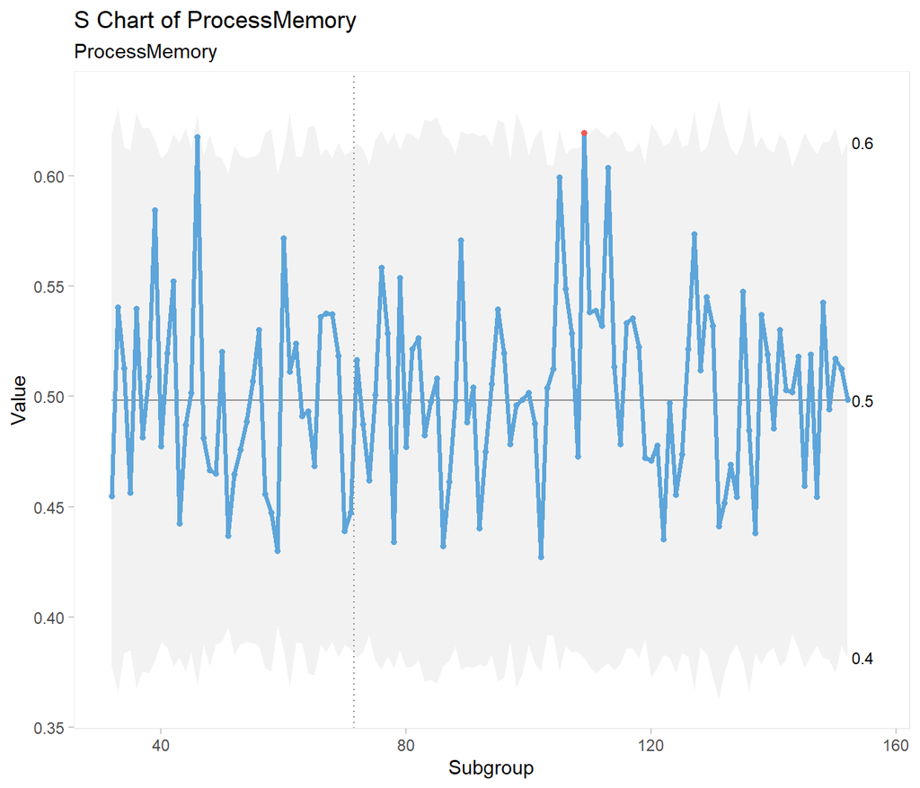

```r
##testing for variability in control
p <- qicharts2::qic(x = DayOfYear, y = ProcessMemory, data = data, chart = "s", subtitle = "ProcessMemory", freeze = control_set)
plot(p)
```

```r
summary(p)
```

```
##   facet1 facet2 part n.obs n.useful longest.run longest.run.max n.crossings
## 1      1      1    1   121      121           7              10          55
##   n.crossings.min runs.signal      aLCL        CL      aUCL sigma.signal
## 1              51           0 0.3806022 0.4983237 0.6160452            1
```

At first glance the variability of process memory looks to be under control because only one point is outside the control limits. Thus, one large shift from the average exists. Furthermore, the longest run value of 7 being smaller than the longest max value of 10 suggests that the the process is in control. Similarly, the n.crossings value of 55 is greater than the in control minimum n.crossings value of 51. Therefore, variability for Process Memory could be seen as in control.

As a whole, the Process Memory is out of control. The next steps will be to investigate the issue on the server side.

### Prediction time

**b. Is the time for model predictions out of control?**

See results for an xbar chart on Prediction Time below:

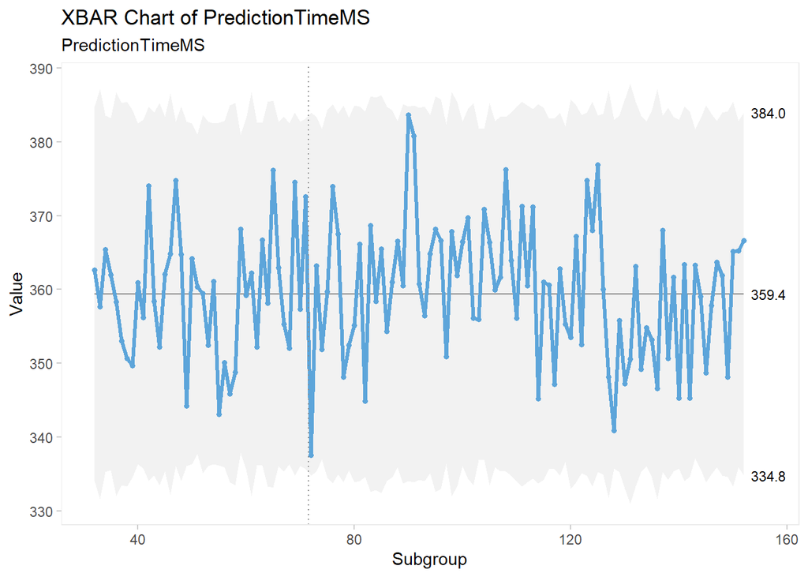

```r
##testing if process means are  in control

p <- qicharts2::qic(x = DayOfYear, y = PredictionTimeMS, data = data, freeze=control_set,chart = "xbar", subtitle = "PredictionTimeMS")
plot(p)
```

```r
summary(p)
```

```
##   facet1 facet2 part n.obs n.useful longest.run longest.run.max n.crossings
## 1      1      1    1   121      121           6              10          66
##   n.crossings.min runs.signal     aLCL       CL     aUCL sigma.signal
## 1              51           0 334.6412 359.3967 384.1521            0
```

Prediction time means look to be in control at first glance, with no point outside the control limit. n.crossings at 66 sits over n.crossings.min at 51 and a longest.run of 6 sits under longest.run.max at 10. Both of these are good indicators of a process being in control.

Below see the results of anSchart for Prediction Time variability:

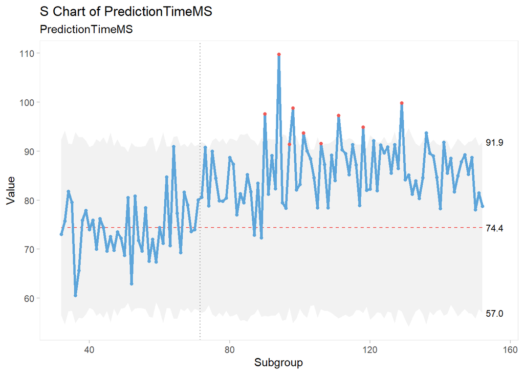

```r
##testing if process variability is in control
p <- qicharts2::qic(x = DayOfYear, y = PredictionTimeMS, data = data, chart = "s", subtitle = "PredictionTimeMS", freeze = control_set)
plot(p)
```

```r
summary(p)
```

```
##   facet1 facet2 part n.obs n.useful longest.run longest.run.max n.crossings
## 1      1      1    1   121      121          63              10          25
##   n.crossings.min runs.signal     aLCL       CL     aUCL sigma.signal
## 1              51           1 56.85666 74.44261 92.02856            9
```

Prediction time variability is out of control with 9 points sitting outside the control limit and a runs signal of 1. Additionally, we see consistent near violation of the limit (4 out of 5 consecutive points greater than 2 standard deviations from the center line) from the subgroup 80 onward, another indicator of a process being out of control.

The process having variability out of control renders the whole Prediction time process out of control.

### Prediction

**c. Do model predictions fall out of control?**

The following details the results of an xbar chart for Predictions:

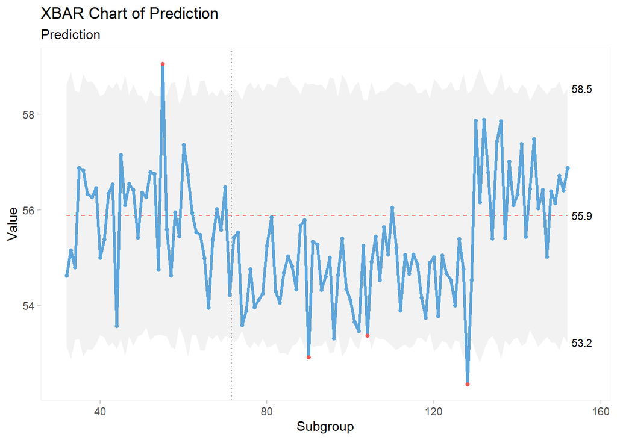

```r
p <- qicharts2::qic(x = DayOfYear, y = Prediction, data = data, freeze=control_set,chart = "xbar", subtitle = "Prediction")
plot(p)
```

```r
summary(p)
```

```
##   facet1 facet2 part n.obs n.useful longest.run longest.run.max n.crossings
## 1      1      1    1   121      121          39              10          29
##   n.crossings.min runs.signal     aLCL       CL     aUCL sigma.signal
## 1              51           1 53.21248 55.88375 58.55502            4
```

Below, see results of anSchart for Prediction:

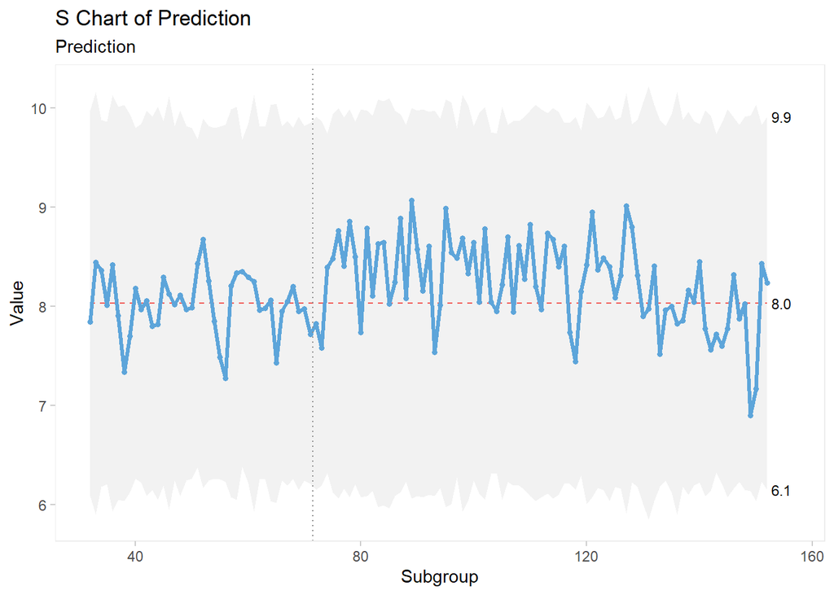

```r
p <- qicharts2::qic(x = DayOfYear, y = Prediction, data = data, chart = "s", subtitle = "Prediction", freeze = control_set)
plot(p)
```

```r
summary(p)
```

```
##   facet1 facet2 part n.obs n.useful longest.run longest.run.max n.crossings
## 1      1      1    1   121      121          11              10          43
##   n.crossings.min runs.signal     aLCL       CL    aUCL sigma.signal
## 1              51           1 6.135191 8.032825 9.93046            0
```

### Summary

Results

[output not shown]